# Exercises

Group 1

### 2.1 Declare Design

* You are not more likely to get a false positive with larger samples. When there is a true effect of some effect power, which is the probability of rejecting the null hypothesis when it is, in fact false, increases, when we have larger samples. If there is no true effect, power is unchanged even as our sample gets larger.

### Assess by generating a simple experimental design from scratch in which we can vary the N and in which there is no true effect of some treatment.

```r
b <-0
N <- 100

simplest_design <-
  declare_model(N = N, U = rnorm(N), potential_outcomes(Y ~ b * Z + U)) + declare_assignment(Z = simple_ra(N), Y = reveal_outcomes(Y ~ Z)) +
  declare_inquiry(ate = mean(Y_Z_1 - Y_Z_0)) +
  declare_estimator(Y ~ Z, inquiry = "ate", .method = lm_robust)

designs <- redesign(simplest_design, N = c(100, 200, 300, 400, 500))

simulations_df <- diagnose_design(designs, sims = 100)

head(simulations_df)
```

```
$simulations_df
      design   N sim_ID inquiry estimand estimator term      estimate
1   design_1 100      1     ate        0 estimator    Z  0.0088383316
2   design_1 100      2     ate        0 estimator    Z  0.2938187317
3   design_1 100      3     ate        0 estimator    Z -0.0574581222
4   design_1 100      4     ate        0 estimator    Z  0.0165475744
5   design_1 100      5     ate        0 estimator    Z  0.3556265888
6   design_1 100      6     ate        0 estimator    Z  0.3166073114
7   design_1 100      7     ate        0 estimator    Z  0.1381515757
8   design_1 100      8     ate        0 estimator    Z  0.0518364102
9   design_1 100      9     ate        0 estimator    Z -0.1428220656
10  design_1 100     10     ate        0 estimator    Z  0.2801531651
11  design_1 100     11     ate        0 estimator    Z -0.0627190527
12  design_1 100     12     ate        0 estimator    Z  0.1764580400
13  design_1 100     13     ate        0 estimator    Z -0.2958306154
```

[output cut: 2033 more lines]

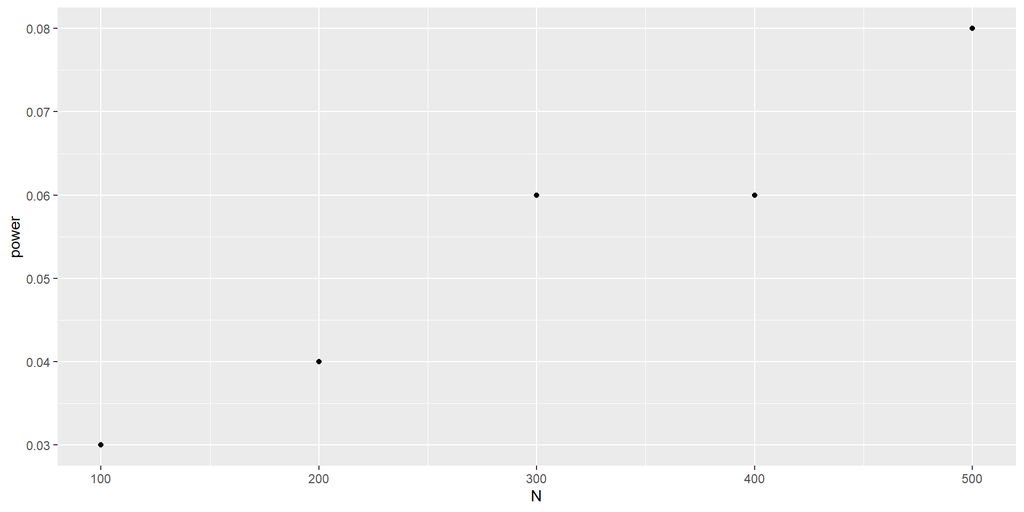

```r
N <- simulations_df$diagnosands_df$N

power <- simulations_df$diagnosands_df$power

ggplot(simulations_df$diagnosands_df, aes(x = N, y = power)) + geom_point()
```

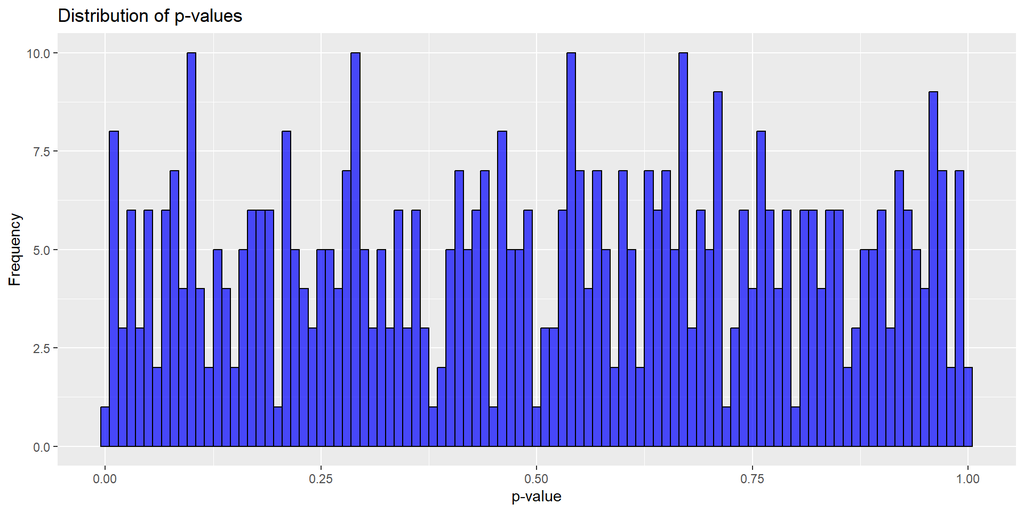

```r
ggplot(simulations_df$simulations_df, aes(x = p.value)) +
  geom_histogram(binwidth = 0.01, fill = "blue", color = "black", alpha = 0.7) +
  labs(title = "Distribution of p-values",
    x = "p-value",
    y = "Frequency")
```

# Plot the distribution of p values from the simulations_df. What shape is it and why?

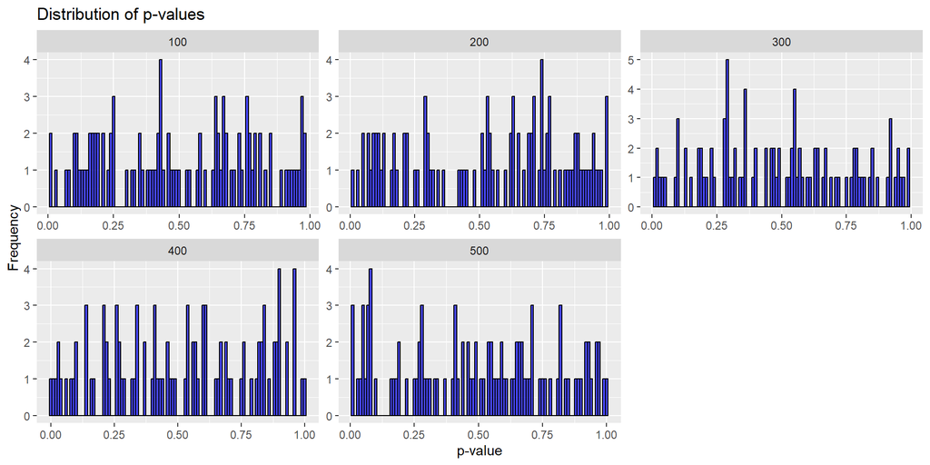

```r
ggplot(simulations_df$simulations_df, aes(x = p.value)) +
  geom_histogram(binwidth = 0.01, fill = "blue", color = "black", alpha = 0.7) +
  labs(title = "Distribution of p-values",
       x = "p-value",
       y = "Frequency") +
  facet_wrap(~N, scales = "free")
```

Uniform distribution because there is no true effect.

estimates vs p.values. More precise estimates with larger N

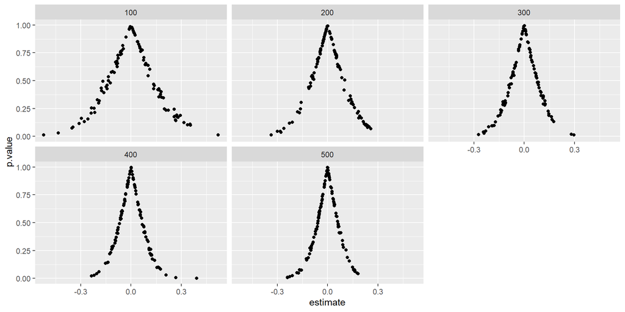

```r
ggplot(simulations_df$simulations_df, aes(x = estimate, y = p.value)) +
  geom_point() +
  facet_wrap(~N)
```

### 3.1 Causality

Potential outcomes

|  | X1 is a necessary and sufficient condition for Y | X1 is necessary but not sufficient | X1 is sufficient but not necessary | X1 sometimes causes Y but is neither necessary nor sufficient |
| --- | --- | --- | --- | --- |
| Y(0,0) = | 0 | 0 | 0 | 0 |
| Y(1,0) = | 1 | 0 | 1 | 1 |
| Y(0,1) = | 0 | 0 | 1 | 1 |
| Y(1,1) = | 1 | 1 | 1 | 0 |

### 4.1 **Collider bias**

Declare a simple design in which (i) X and Y both have a positive effect on K (binary) but X does not cause Y (ii) a researcher conditions on K == 1 when estimating the effect of X on Y.

```r
set.seed(12)
dagify(K ~ X,
       K ~ Y,
       outcome = "K",
       exposure = c("X", "Y"),
       labels = c("K" = "K==1")) |>
  ggdag(use_labels = "label")+
  theme_dag()
```

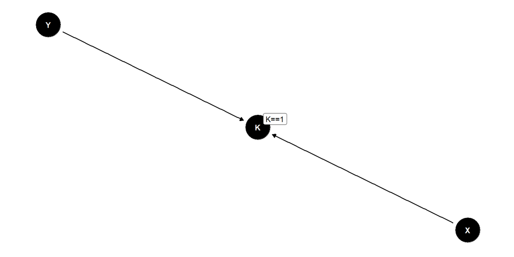

Show that this can generate biased results. Can you find situations where the bias can be either positive or negative?

```r
M1 <-
  declare_model(
    N = 1000,
    X = rnorm(N),
    Y = rnorm(N),
    K = rbinom(N, 1, prob = pnorm(X + Y))) +
  declare_inquiry(Ybar = mean(Y[X==1])) +
  declare_sampling(S = simple_rs(N, prob = 0.2),
                   filter = S == 1) +
  declare_estimator(
    Y ~ X,
    .method = lm_robust,
    .summary = tidy,
    term = "X",
    inquiry = "ATE",
    label = "OLS",
    subset = K == 1
  )

M1$model()
```

```
       ID             X            Y K
1    0001  5.532073e-01 -0.357769740 1
2    0002 -9.117159e-01  1.304172911 1
3    0003  2.548312e-01 -0.733813986 0
4    0004 -1.011266e+00  0.782325130 0
5    0005 -1.437375e+00 -0.624215407 0
6    0006 -9.347590e-01  0.322433166 0
7    0007 -9.091552e-01 -0.274161396 0
8    0008  7.598188e-01  0.068341008 1
9    0009  7.502208e-02  1.398044945 1
10   0010  1.197167e+00  0.033665868 1
11   0011 -8.299286e-01 -0.661891776 0
12   0012 -4.109039e-01 -1.525796100 0
13   0013 -1.077819e-01  0.564087536 0
14   0014  1.005789e-01  0.254475371 1
```

[output cut: 986 more lines]

```r
sim_data <- draw_data(M1)
estimates <- draw_estimates(M1)

diagnose_design(M1)
```

```
Research design diagnosis based on 500 simulations. Diagnosis completed in 4 secs. Diagnosand estimates with bootstrapped standard errors in parentheses (100 replicates).

 Design Inquiry Estimator Outcome Term N Sims Mean Estimand Mean Estimate Bias
     M1     ATE       OLS       Y    X    500            NA         -0.28   NA
                                                         NA        (0.00)   NA
     M1    Ybar      <NA>    <NA> <NA>    500           NaN            NA   NA
                                                         NA            NA   NA
 SD Estimate RMSE  Power Coverage
        0.10   NA   0.79       NA
      (0.00)   NA (0.02)       NA
          NA   NA     NA       NA
          NA   NA     NA       NA
```

```r
simulations_df <- diagnose_design(M1, sims = 100)
simulations_df
```

```
Research design diagnosis based on 100 simulations. Diagnosis completed in 1 secs. Diagnosand estimates with bootstrapped standard errors in parentheses (100 replicates).

 Design Inquiry Estimator Outcome Term N Sims Mean Estimand Mean Estimate Bias
     M1     ATE       OLS       Y    X    100            NA         -0.26   NA
                                                         NA        (0.01)   NA
     M1    Ybar      <NA>    <NA> <NA>    100           NaN            NA   NA
                                                         NA            NA   NA
 SD Estimate RMSE  Power Coverage
        0.09   NA   0.77       NA
      (0.01)   NA (0.05)       NA
          NA   NA     NA       NA
          NA   NA     NA       NA
```

| Block | Z | Y |
| --- | --- | --- |
| 1 | 0 | 0 |
| 1 | 0 | 0 |
| 1 | 1 | 1 |
| 2 | 0 | 0 |
| 2 | 0 | 0 |
| 2 | 0 | 1 |
| 2 | 1 | 0 |
| 2 | 1 | 1 |
| 2 | 1 | 1 |

- Can you estimate the ATE? How about the ATT? And the ATC?

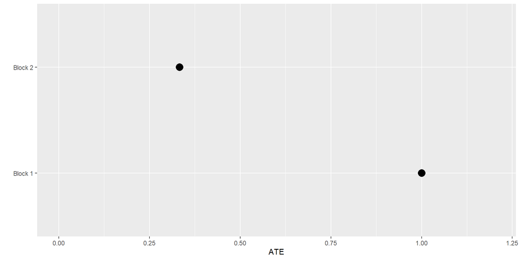

  ```r
  # 5.1
  table_data <- html_table(table_5_1, fill = TRUE)[[5]] %>%
    rename("Treat" = "Z",
           "Outcome" = "Y")

  # Calculating ATE (ATT and ATU would require pre-treatment observations)
  mean_treatment_1 <- mean(table_data$Outcome[table_data$Block == "1" &
                                                table_data$Treat == "1"])
  mean_control_1 <- mean(table_data$Outcome[table_data$Block == "1" &
                                              table_data$Treat == "0"])

  mean_treatment_2 <- mean(table_data$Outcome[table_data$Block == "2" &
                                                table_data$Treat == "1"])
  mean_control_2 <- mean(table_data$Outcome[table_data$Block == "2" &
                                              table_data$Treat == "0"])

  ate_1 <- mean_treatment_1 - mean_control_1
  ate_2 <- mean_treatment_2 - mean_control_2


  # Plot
  df_ate <- data.frame(Block = c("Block 1", "Block 2"),
                       ATE = c(ate_1, ate_2))

  plot_ate <- ggplot(df_ate, aes(x = Block, y = ATE)) +
    geom_point(aes(size = 3)) +
    scale_size(guide = "none") +
    lims(y = c(0, 1.2)) +
    coord_flip() +
    labs(x = "")

  plot_ate
  ```

- How do these compare to a simple difference in means between treatment and control?
- Use `DeclareDesign` to compare the answers you get if you use (1) OLS and controlled for block (2) IPW and (3) the Lin estimator
- Imagine now letting the size of the data increase by a factor k — meaning that if k=2 increase you would have twice as many units in each block. Show how the precision of your estimates changes under these different strategies as k increases